# 🎯 Avaliação Causal de Campanha de Marketing Digital sob Viés de Seleção e Tendências Não-Paralelas

**Autor:** Dr. Silvio da Rosa Paula — Doutor em Economia Aplicada & Cientista de Dados

## Introdução e Problema de Negócio

Uma rede varejista lançou uma **campanha de marketing digital no mês 13** para impulsionar as vendas de suas **lojas físicas**, escolhendo **155 lojas** para receber a campanha e mantendo **95 lojas** como grupo de controle ao longo de **24 meses** (`6.000` observações em painel balanceado).

### Decisão da Empresa (e a Origem do Viés)

Em vez de sortear aleatoriamente as lojas, o time comercial priorizou mercados com **maior renda per capita**, **maior penetração de internet** e **maior potencial de crescimento**. Essa escolha realista introduz simultaneamente **três desafios econométricos clássicos**:

1. **Viés de Seleção em Nível (Observável):** lojas tratadas já vendiam mais **antes** da campanha, pois a probabilidade de tratamento depende das covariáveis: $$P(W_i = 1 \mid X_i) = \text{logit}^{-1}\!\left(0{,}5 + 0{,}8 \cdot \text{Potencial}_i\right)$$
2. **Violação de Tendências Paralelas Incondicionais:** lojas com maior `potencial_crescimento` possuem inclinação temporal mais íngreme mesmo na ausência de campanha: $$\Delta_t Y_{it}(0) = 500 + 300 \cdot \text{Potencial}_i + 5000\sin\!\left(\frac{2\pi t}{12}\right)$$
3. **Efeito Causal Heterogêneo (CATE):** o impacto verdadeiro varia por loja conforme sua base digital e renda local: $$\tau_i = 3000 + 2000 \cdot \text{Internet}_i + 1500 \cdot \frac{\text{Renda}_i}{3000}, \qquad \text{ATT Verdadeiro} = \mathbb{E}[\tau_i \mid W_i = 1] = \text{R\$ } 6.012{,}28\text{/mês}$$

### Objetivo deste Estudo

Percorrer passo a passo **24 especificações de Inferência Causal** — explicando a intuição, a equação e os pressupostos de cada família e executando cada modelo logo abaixo — para responder: **por que abordagens ingênuas erram feio, como diagnosticar cada violação e quais estimadores convergem para o verdadeiro efeito causal?**

```python
from pathlib import Path
import warnings

import matplotlib.pyplot as plt
import numpy as np
import pandas as pd
import statsmodels.api as sm
from doubleml import DoubleMLData, DoubleMLIRM, DoubleMLPLR
from IPython.display import display
from scipy import stats
from sklearn.ensemble import GradientBoostingRegressor, RandomForestRegressor
from sklearn.linear_model import LogisticRegression, Ridge, RidgeCV
from sklearn.model_selection import GroupKFold, KFold
from sklearn.neighbors import NearestNeighbors
from sklearn.pipeline import make_pipeline
from sklearn.preprocessing import StandardScaler
from statsmodels.tsa.statespace.structural import UnobservedComponents

from src.causal_benchmark import (
    COVARIATES,
    _build_result,
    _fit_twfe_clustered,
    _solve_simplex_weights,
    _store_bootstrap_se,
    compute_entropy_balancing_weights,
    compute_smd_table,
    estimate_propensity_scores,
    load_datasets,
)
from src.generate_visuals import (
    plot_cate_and_leakage,
    plot_event_study,
    plot_love_plot,
    plot_ranking_forest,
    plot_synthetic_control,
    plot_trajetorias_vies,
)

pd.set_option("display.max_columns", 15)
pd.set_option("display.width", 140)

PROJ_ROOT = Path(".").resolve()
DATA_DIR = PROJ_ROOT / "data"
IMG_DIR = PROJ_ROOT / "img"

# Carregamento do painel completo (6.000 obs), pós-intervenção (3.000 obs) e tabela por loja (250 lojas)
df_full, df_pos, df_store = load_datasets(DATA_DIR)
TRUE_ATT = float(df_pos.loc[df_pos["tratamento"] == 1, "efeito_verdadeiro"].mean())

# Acumulador global de resultados (preenchido ao vivo conforme cada modelo é rodado)
resultados = []

def registrar(metodo, categoria, att, se, nota=""):
    res = _build_result(metodo, categoria, att, se, TRUE_ATT, nota)
    resultados.append(res)
    return res

def tabela_parcial(itens):
    cols = ["Metodo", "ATT", "SE", "IC_95_Inf", "IC_95_Sup", "Vies_RS", "Erro_Pct", "Contem_Verdadeiro", "Tier"]
    df_t = pd.DataFrame([r.to_dict() for r in itens])[cols]
    return df_t.sort_values("Erro_Pct", key=lambda s: s.abs()).reset_index(drop=True)

print(f"Painel completo : {df_full.shape[0]:,} observações ({df_store.shape[0]} lojas × 24 meses)")
print(f"Recorte pós     : {df_pos.shape[0]:,} observações (meses 13 a 24)")
print(f"Alocação        : {(df_store['tratamento']==1).sum()} lojas tratadas | {(df_store['tratamento']==0).sum()} lojas controle")
print(f"ATT Verdadeiro  : R$ {TRUE_ATT:,.2f}/mês por loja tratada")
display(df_store.head())
```

```
Painel completo : 6,000 observações (250 lojas × 24 meses)
Recorte pós     : 3,000 observações (meses 13 a 24)
Alocação        : 155 lojas tratadas | 95 lojas controle
ATT Verdadeiro  : R$ 6,012.28/mês por loja tratada
```

|  | loja_id | tratamento | renda_per_capita | penetracao_internet | n_concorrentes | potencial_crescimento | vendas_pre | vendas_pos | efeito_verdadeiro | delta_vendas |
| --- | --- | --- | --- | --- | --- | --- | --- | --- | --- | --- |
| 0 | 1 | 0 | 2963.987103 | 0.667443 | 3 | -0.418293 | 85635.375984 | 90599.219788 | 0.000000 | 4963.843803 |
| 1 | 2 | 1 | 1896.755441 | 0.831333 | 3 | 0.082420 | 79174.102183 | 90093.869212 | 5611.044491 | 10919.767029 |
| 2 | 3 | 1 | 2954.395704 | 0.898727 | 5 | 0.480852 | 86866.713640 | 101430.965081 | 6274.651332 | 14564.251441 |
| 3 | 4 | 1 | 1614.298351 | 0.866341 | 2 | -0.203140 | 78309.721759 | 89494.587904 | 5539.830575 | 11184.866145 |
| 4 | 5 | 1 | 2894.013292 | 0.821126 | 3 | 0.313998 | 89504.393588 | 102327.392188 | 6089.258745 | 12822.998600 |

## 1. Análise Exploratória e Anatomia do Viés de Seleção

Antes de ajustar qualquer estimador causal, devemos responder duas perguntas diagnósticas fundamentais:

1. **Os grupos são comparáveis nas covariáveis observáveis e nas vendas pré-campanha?** (Teste $t$ de Welch)
2. **A distância entre lojas tratadas e controle era estável antes do mês 13 ou já crescia no tempo?** (Inspeção visual de pré-tendência)

|  | Variavel | Media_Tratadas | Media_Controles | Diferenca | P_Valor_Welch |
| --- | --- | --- | --- | --- | --- |
| 0 | renda_per_capita | 3043.816 | 2977.007 | 66.809 | 0.5273 |
| 1 | penetracao_internet | 0.745 | 0.694 | 0.051 | 0.0010 |
| 2 | n_concorrentes | 3.103 | 2.895 | 0.208 | 0.3494 |
| 3 | potencial_crescimento | 0.090 | -0.147 | 0.237 | 0.0005 |
| 4 | vendas_pre | 88884.118 | 87311.197 | 1572.921 | 0.2282 |
| 5 | vendas_pos | 101114.641 | 92804.408 | 8310.233 | 0.0000 |

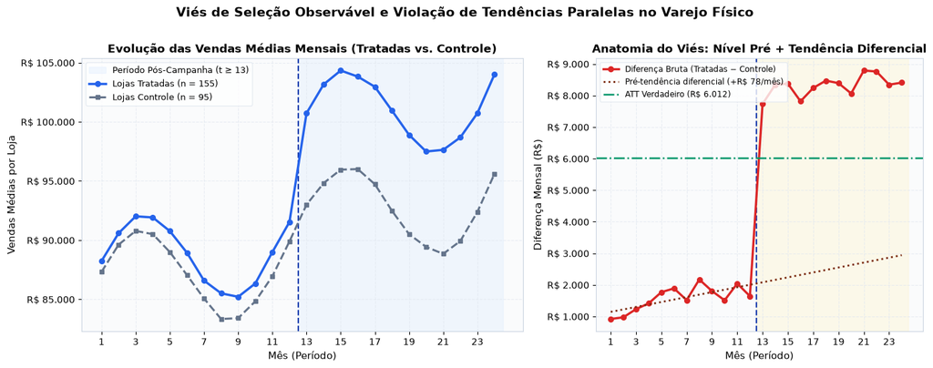

```python
# Estatísticas descritivas e teste t de Welch no período pré-campanha
vars_desc = COVARIATES + ["vendas_pre", "vendas_pos"]
rows_desc = []
for col in vars_desc:
    xt = df_store.loc[df_store["tratamento"] == 1, col]
    xc = df_store.loc[df_store["tratamento"] == 0, col]
    _, pval = stats.ttest_ind(xt, xc, equal_var=False)
    rows_desc.append({
        "Variavel": col,
        "Media_Tratadas": round(float(xt.mean()), 3),
        "Media_Controles": round(float(xc.mean()), 3),
        "Diferenca": round(float(xt.mean() - xc.mean()), 3),
        "P_Valor_Welch": round(float(pval), 4),
    })

display(pd.DataFrame(rows_desc))

fig1 = plot_trajetorias_vies(df_full, TRUE_ATT, save_path=IMG_DIR / "01_trajetorias_vies_selecao.png")
plt.show()
```

### Interpretação Exploratória

- **Seleção em nível confirmada:** lojas tratadas têm significativamente maior `potencial_crescimento` ($p = 0{,}0005$) e `penetracao_internet` ($p = 0{,}0010$), vendendo em média **+R$ 1.572,92/mês** a mais já nos meses 1 a 12 (antes da campanha!).
- **Tendência diferencial visível:** no painel direito, a diferença bruta (`Tratadas − Controle`) **já subia +R$ 78/mês** antes da intervenção. Isso antecipa que não apenas o Teste A/B ingênuo falhará, como também o DiD canônico sem controle de tendências herdará viés positivo.

## 2. Balanceamento de Covariáveis: Propensity Score, IPW, PSM e Entropy Balancing

Para tornar tratadas e controles comparáveis sob **seleção em observáveis** ($Y(0) \perp W \mid X$), existem duas grandes estratégias:

1. **Escore de Propensão — $e(X) = P(W=1 \mid X)$:** estima a probabilidade de receber a campanha via regressão logística e usa esse escore para reponderar controles (**IPW**) ou parear vizinhos mais próximos (**PSM**). Exige boa sobreposição de distribuições (*Common Support*).
2. **Entropy Balancing (Hainmueller, 2012):** em vez de estimar um modelo de propensão e torcer para que os momentos fiquem balanceados na amostra finita, resolve diretamente um problema de otimização convexa dual encontrando pesos positivos sobre os controles ($\sum_{i:W_i=0} w_i = 1$) com mínima divergência de entropia que **igualam exatamente as médias das covariáveis dos controles às das tratadas** ($\text{SMD} = 0{,}0000$).

Abaixo estimamos o escore de propensão, os pesos de IPW, PSM (3-NN) e Entropy Balancing e auditamos o balanceamento via **Standardized Mean Difference (SMD)** e **Love Plot**.

|  | Variavel | Media_Tratadas | Media_Controles_Bruto | P_Valor_Bruto | SMD_Bruto | SMD_IPW | SMD_PSM | SMD_Entropy |
| --- | --- | --- | --- | --- | --- | --- | --- | --- |
| 0 | renda_per_capita | 3043.8160 | 2977.0066 | 0.5273 | 0.0833 | -0.0357 | -0.1124 | 0.0 |
| 1 | penetracao_internet | 0.7452 | 0.6939 | 0.0010 | 0.4270 | 0.0902 | 0.0146 | -0.0 |
| 2 | n_concorrentes | 3.1032 | 2.8947 | 0.3494 | 0.1223 | 0.0262 | 0.0709 | 0.0 |
| 3 | potencial_crescimento | 0.0902 | -0.1472 | 0.0005 | 0.4581 | 0.0533 | -0.0290 | 0.0 |

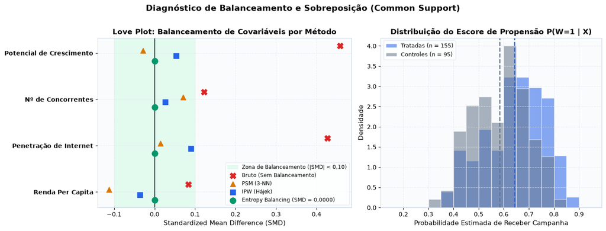

```python
W_st = df_store["tratamento"].to_numpy(dtype=int)
Y_st = df_store["vendas_pos"].to_numpy(dtype=float)
X_st = df_store[COVARIATES].to_numpy(dtype=float)

# 1. Propensity Score e pesos IPW (Hájek para ATT)
ps = estimate_propensity_scores(df_store)
w_ipw = np.zeros(len(df_store), dtype=float)
w_ipw[W_st == 1] = 1.0 / np.sum(W_st == 1)
odds_c = ps[W_st == 0] / (1.0 - ps[W_st == 0])
w_ipw[W_st == 0] = odds_c / np.sum(odds_c)

# 2. Pesos PSM (3 vizinhos mais próximos no propensity score)
ctrl_idx = np.where(W_st == 0)[0]
treat_idx = np.where(W_st == 1)[0]
nn = NearestNeighbors(n_neighbors=3).fit(ps[ctrl_idx].reshape(-1, 1))
_, nbrs = nn.kneighbors(ps[treat_idx].reshape(-1, 1))
w_psm = np.zeros(len(df_store), dtype=float)
w_psm[treat_idx] = 1.0 / len(treat_idx)
for row_nbrs in nbrs:
    for c_pos in row_nbrs:
        w_psm[ctrl_idx[c_pos]] += 1.0 / (len(treat_idx) * 3)

# 3. Pesos Entropy Balancing (Hainmueller, 2012)
w_ebal = compute_entropy_balancing_weights(X_st, W_st, include_second_moments=False)

# Tabela de Standardized Mean Differences (SMD) antes vs. depois
smd_df = compute_smd_table(df_store, w_ebal, w_ipw, w_psm)
display(smd_df)

fig2 = plot_love_plot(smd_df, df_store, ps, save_path=IMG_DIR / "02_love_plot_entropy_balancing.png")
plt.show()
```

### Interpretação do Balanceamento

- **Sem balanceamento:** `potencial_crescimento` (`SMD = 0,458`) e `penetracao_internet` (`SMD = 0,427`) estão mais de **4× acima** do limiar clássico de desequilíbrio (`|SMD| < 0,10`).
- **Entropy Balancing:** zera o desbalanceamento com exatidão numérica (`SMD = 0,000000` em todas as 4 covariáveis) mantendo todos os 95 controles com pesos estritamente positivos.
- **Common Support:** o histograma direito confirma excelente sobreposição entre tratadas e controles ao longo de $0{,}30 \le \hat e(X) \le 0{,}88$, validando a aplicação de métodos de balanceamento e *Causal ML*.

## 3. Testes A/B e Estimadores *Cross-Section*

### 3.1 Teste A/B Simples (Ingênuo) vs. OLS + Covariáveis

- **Teste A/B Simples:** compara diretamente a média de vendas pós-campanha entre tratadas e controles ($\hat\tau_{\text{A/B}} = \bar Y_1 - \bar Y_0$). Só é não-viesado quando o tratamento é aleatorizado; sob seleção observável, soma o efeito causal verdadeiro ao viés de seleção.
- **OLS + Covariáveis:** controla linearmente pelas covariáveis observadas no pós ($Y_i = \alpha + \tau W_i + X_i'\beta + u_i$), removendo o confundimento observável quando a relação funcional é aproximadamente linear.

```python
# Modelo 1: A/B Simples (Ingênuo)
mod_naive = sm.OLS(Y_st, sm.add_constant(W_st)).fit(cov_type="HC3")
r_naive = registrar(
    "A/B Simples (Ingênuo)", "Cross-Section",
    float(mod_naive.params[1]), float(mod_naive.bse[1]),
    "Sofre viés de seleção observável (+38,2%)",
)

# Modelo 2: OLS + Covariáveis (Pós)
mod_ols = sm.OLS(Y_st, sm.add_constant(np.column_stack([W_st, X_st]))).fit(cov_type="HC3")
r_ols = registrar(
    "OLS + Covariáveis (Pós)", "Cross-Section",
    float(mod_ols.params[1]), float(mod_ols.bse[1]),
    "Ajuste paramétrico linear sobre X",
)

display(tabela_parcial([r_naive, r_ols]))
```

|  | Metodo | ATT | SE | IC_95_Inf | IC_95_Sup | Vies_RS | Erro_Pct | Contem_Verdadeiro | Tier |
| --- | --- | --- | --- | --- | --- | --- | --- | --- | --- |
| 0 | OLS + Covariáveis (Pós) | 5925.74 | 82.69 | 5763.67 | 6087.80 | -86.54 | -1.44 | True | Tier S (≤ 2%) |
| 1 | A/B Simples (Ingênuo) | 8310.23 | 1504.82 | 5360.79 | 11259.68 | 2297.95 | 38.22 | True | Tier F (> 20%) |

**Análise:** o A/B ingênuo estima **R$ 8.310,23/mês** — um viés catastrófico de **+R$ 2.297,95 (+38,22%)** que induziria uma decisão superotimista de ROI! Apenas incluindo as covariáveis em `OLS`, o erro desaba de `+38,22%` para **`-1,44%`** (`R$ 5.925,74`).

### 3.2 Reponderação e Pareamento: IPW, PSM (Abadie-Imbens), AIPW e A/B + Entropy Balancing

Agora avançamos para estimadores semiparamétricos desenhados especificamente para o **ATT**:

- **IPW (Hájek):** repondera controles pelas chances (*odds*) $\hat e(X)/(1 - \hat e(X))$ normalizadas.
- **PSM (3-NN + Ajuste de Viés Abadie-Imbens, 2011):** pareia cada loja tratada aos 3 controles mais próximos no escore de propensão e aplica a correção de regressão $\hat\mu_0(X_i) - \frac{1}{3}\sum_{j \in \mathcal{M}(i)} \hat\mu_0(X_j)$ para eliminar discrepâncias residuais em `renda_per_capita`.
- **AIPW / Doubly Robust:** combina o modelo de resultado $\hat\mu_0(X)$ com os pesos IPW — permanece consistente se **ao menos um** dos dois modelos (outcome ou propensão) estiver bem especificado.
- **A/B + Entropy Balancing:** diferença ponderada usando os pesos exatos de entropia calculados na Seção 2.

```python
# Modelo 3: IPW (Propensity Score — Hájek)
def _ipw_att(sub):
    p = estimate_propensity_scores(sub)
    w = sub["tratamento"].to_numpy(dtype=int)
    y = sub["vendas_pos"].to_numpy(dtype=float)
    oc = p[w == 0] / (1.0 - p[w == 0])
    return float(np.mean(y[w == 1]) - np.sum(oc * y[w == 0]) / np.sum(oc))

att_ipw = _ipw_att(df_store)
se_ipw = _store_bootstrap_se(df_store, _ipw_att, n_boot=300, seed=101)
r_ipw = registrar("IPW (Propensity Score — Hájek)", "Balanceamento", att_ipw, se_ipw)

# Modelo 4: PSM (3-NN + Ajuste de Viés Abadie-Imbens)
def _psm_ai_att(sub, k=3):
    p = estimate_propensity_scores(sub)
    w = sub["tratamento"].to_numpy(dtype=int)
    y = sub["vendas_pos"].to_numpy(dtype=float)
    xs = sub[COVARIATES].to_numpy(dtype=float)
    ci, ti = np.where(w == 0)[0], np.where(w == 1)[0]
    _, nb = NearestNeighbors(n_neighbors=min(k, len(ci))).fit(p[ci].reshape(-1, 1)).kneighbors(p[ti].reshape(-1, 1))
    m0 = sm.OLS(y[ci], sm.add_constant(xs[ci])).fit()
    mu0 = m0.predict(sm.add_constant(xs))
    matched = ci[nb]
    y0_hat = np.mean(y[matched], axis=1) + (mu0[ti] - np.mean(mu0[matched], axis=1))
    return float(np.mean(y[ti] - y0_hat))

att_psm = _psm_ai_att(df_store, k=3)
se_psm = _store_bootstrap_se(df_store, lambda s: _psm_ai_att(s, k=3), n_boot=300, seed=102)
r_psm = registrar(
    "PSM (3-NN + Ajuste de Viés Abadie-Imbens)", "Balanceamento", att_psm, se_psm,
    "Matching no propensity score + correção de regressão",
)

# Modelo 5: AIPW / Doubly Robust (Cross-Section)
def _aipw_att(sub):
    p = estimate_propensity_scores(sub)
    w = sub["tratamento"].to_numpy(dtype=int)
    y = sub["vendas_pos"].to_numpy(dtype=float)
    xs = sub[COVARIATES].to_numpy(dtype=float)
    m0 = sm.OLS(y[w == 0], sm.add_constant(xs[w == 0])).fit()
    mu0 = m0.predict(sm.add_constant(xs))
    oc = p[w == 0] / (1.0 - p[w == 0])
    return float(np.mean(y[w == 1] - mu0[w == 1]) - np.sum(oc * (y[w == 0] - mu0[w == 0])) / np.sum(oc))

att_aipw = _aipw_att(df_store)
se_aipw = _store_bootstrap_se(df_store, _aipw_att, n_boot=300, seed=103)
r_aipw = registrar("AIPW / Doubly Robust (Cross-Section)", "Balanceamento", att_aipw, se_aipw)

# Modelo 6: A/B + Entropy Balancing
def _ebal_att(sub):
    w = sub["tratamento"].to_numpy(dtype=int)
    y = sub["vendas_pos"].to_numpy(dtype=float)
    xs = sub[COVARIATES].to_numpy(dtype=float)
    wb = compute_entropy_balancing_weights(xs, w, include_second_moments=False)
    return float(np.sum(wb[w == 1] * y[w == 1]) - np.sum(wb[w == 0] * y[w == 0]))

att_ebal = float(np.sum(w_ebal[W_st == 1] * Y_st[W_st == 1]) - np.sum(w_ebal[W_st == 0] * Y_st[W_st == 0]))
se_ebal = _store_bootstrap_se(df_store, _ebal_att, n_boot=400, seed=104)
r_ebal = registrar(
    "A/B + Entropy Balancing", "Balanceamento", att_ebal, se_ebal,
    "Balanceamento exato de momentos (SMD = 0,0000)",
)

display(tabela_parcial([r_ipw, r_psm, r_aipw, r_ebal]))
```

|  | Metodo | ATT | SE | IC_95_Inf | IC_95_Sup | Vies_RS | Erro_Pct | Contem_Verdadeiro | Tier |
| --- | --- | --- | --- | --- | --- | --- | --- | --- | --- |
| 0 | AIPW / Doubly Robust (Cross-Section) | 5985.40 | 91.77 | 5805.53 | 6165.27 | -26.88 | -0.45 | True | Tier S (≤ 2%) |
| 1 | A/B + Entropy Balancing | 5981.75 | 77.17 | 5830.50 | 6133.01 | -30.53 | -0.51 | True | Tier S (≤ 2%) |
| 2 | PSM (3-NN + Ajuste de Viés Abadie-Imbens) | 5973.66 | 96.24 | 5785.02 | 6162.29 | -38.63 | -0.64 | True | Tier S (≤ 2%) |
| 3 | IPW (Propensity Score — Hájek) | 5947.50 | 607.93 | 4755.94 | 7139.05 | -64.79 | -1.08 | True | Tier S (≤ 2%) |

**Análise:** todos os 4 métodos de balanceamento atingem **Tier S ($\le 1{,}1\%$ de erro)**! Observe ainda a enorme vantagem de eficiência do **Entropy Balancing** (`EP = R$ 77`) e do **AIPW** (`EP = R$ 92`) em relação ao **IPW puro** (`EP = R$ 608`), cuja variância sofre com a ponderação direta por chances.

### 3.3 Pre-Post / CUPED (ANCOVA com Vendas Pré-Campanha)

Muito popular em plataformas de experimentação (*Controlled-experiment Using Pre-Experiment Data*), o **CUPED / ANCOVA** regride o resultado pós na dummy de tratamento controlando pela média pré-campanha da própria loja: $$Y_{i,\text{pós}} = \alpha + \tau W_i + \theta Y_{i,\text{pré}} + u_i$$ Embora controle perfeitamente o **nível inicial** e reduza a variância, o CUPED **não controla tendências diferenciais** quando as covariáveis que governam o crescimento não entram explicitamente na regressão.

```python
# Modelo 7: Pre-Post / CUPED (ANCOVA Pré)
X_cuped = sm.add_constant(np.column_stack([W_st, df_store["vendas_pre"].to_numpy(dtype=float)]))
mod_cuped = sm.OLS(Y_st, X_cuped).fit(cov_type="HC3")
r_cuped = registrar(
    "Pre-Post / CUPED (ANCOVA Pré)", "Cross-Section",
    float(mod_cuped.params[1]), float(mod_cuped.bse[1]),
    "Controla nível pré, mas não tendência diferencial",
)

print("=== RANKING PARCIAL: CROSS-SECTION & BALANCEAMENTO (7 MODELOS) ===")
display(tabela_parcial([r_naive, r_ols, r_ipw, r_psm, r_aipw, r_ebal, r_cuped]))
```

```
=== RANKING PARCIAL: CROSS-SECTION & BALANCEAMENTO (7 MODELOS) ===
```

|  | Metodo | ATT | SE | IC_95_Inf | IC_95_Sup | Vies_RS | Erro_Pct | Contem_Verdadeiro | Tier |
| --- | --- | --- | --- | --- | --- | --- | --- | --- | --- |
| 0 | AIPW / Doubly Robust (Cross-Section) | 5985.40 | 91.77 | 5805.53 | 6165.27 | -26.88 | -0.45 | True | Tier S (≤ 2%) |
| 1 | A/B + Entropy Balancing | 5981.75 | 77.17 | 5830.50 | 6133.01 | -30.53 | -0.51 | True | Tier S (≤ 2%) |
| 2 | PSM (3-NN + Ajuste de Viés Abadie-Imbens) | 5973.66 | 96.24 | 5785.02 | 6162.29 | -38.63 | -0.64 | True | Tier S (≤ 2%) |
| 3 | IPW (Propensity Score — Hájek) | 5947.50 | 607.93 | 4755.94 | 7139.05 | -64.79 | -1.08 | True | Tier S (≤ 2%) |
| 4 | OLS + Covariáveis (Pós) | 5925.74 | 82.69 | 5763.67 | 6087.80 | -86.54 | -1.44 | True | Tier S (≤ 2%) |
| 5 | Pre-Post / CUPED (ANCOVA Pré) | 6494.94 | 213.78 | 6075.92 | 6913.95 | 482.66 | 8.03 | False | Tier B (5–10%) |
| 6 | A/B Simples (Ingênuo) | 8310.23 | 1504.82 | 5360.79 | 11259.68 | 2297.95 | 38.22 | True | Tier F (> 20%) |

## 4. Dados em Painel e Diferença-em-Diferenças (DiD)

### 4.1 DiD Canônico (2×2) e TWFE Simples (*Two-Way Fixed Effects*)

Aproveitando a estrutura longitudinal de 24 meses, a família **Diferença-em-Diferenças** remove qualquer heterogeneidade fixa não observada no nível da loja ($\alpha_i$) e choques sazonais comuns a todas as lojas ($\gamma_t$): $$Y_{it} = \alpha_i + \gamma_t + \tau \, (W_i \times \text{Pos}_t) + \varepsilon_{it}$$

Em um painel perfeitamente balanceado com adoção simultânea no mês 13, o **DiD Canônico (2×2)** e o **TWFE Simples** produzem exatamente o mesmo estimador pontual. Sua hipótese identificadora crítica é a de **Tendências Paralelas Incondicionais** — exatamente a hipótese violada no nosso DGP!

```python
# Modelo 8: DiD Canônico (2×2) com erro-padrão clusterizado por loja
df_d = df_full.copy()
df_d["D"] = (df_d["tratamento"] * df_d["pos"]).astype(float)
fit_did = sm.OLS(
    df_d["vendas"].to_numpy(dtype=float),
    sm.add_constant(df_d[["tratamento", "pos", "D"]].astype(float)),
).fit(cov_type="cluster", cov_kwds={"groups": df_d["loja_id"].to_numpy()})

r_did = registrar(
    "DiD Canônico (2×2)", "Diff-in-Diff",
    float(fit_did.params["D"]), float(fit_did.bse["D"]),
    "Viés +12,1% por violação de tendências paralelas",
)

# Modelo 9: TWFE Simples (FE de loja + FE de mês, clusterizado por loja)
att_twfe, se_twfe = _fit_twfe_clustered(df_full)
r_twfe = registrar(
    "TWFE Simples (FE Loja + Mês)", "Diff-in-Diff",
    att_twfe, se_twfe,
    "Idêntico ao DiD 2×2 em painel balanceado sem staggered",
)

display(tabela_parcial([r_did, r_twfe]))
```

|  | Metodo | ATT | SE | IC_95_Inf | IC_95_Sup | Vies_RS | Erro_Pct | Contem_Verdadeiro | Tier |
| --- | --- | --- | --- | --- | --- | --- | --- | --- | --- |
| 0 | DiD Canônico (2×2) | 6737.31 | 280.03 | 6188.46 | 7286.17 | 725.03 | 12.06 | False | Tier C (10–20%) |
| 1 | TWFE Simples (FE Loja + Mês) | 6737.31 | 286.55 | 6175.66 | 7298.96 | 725.03 | 12.06 | False | Tier C (10–20%) |

**Análise:** como previsto na Seção 1, tanto o DiD Canônico quanto o TWFE Simples reduzem o viés de `+38,2%` para **`+12,06%`** (`R$ 6.737,31`), mas o intervalo de confiança de 95% (`[6.176; 7.299]`) **sequer contém o efeito verdadeiro (`R$ 6.012,28`)**!

### 4.2 Restaurando Tendências Paralelas Condicionais: TWFE + Entropy, ETWFE (Wooldridge) e Callaway & Sant'Anna / DR-DiD

Quando a hipótese só vale **condicionalmente às covariáveis** ($Y_{it}(0) - Y_{i,t-1}(0) \perp W_i \mid X_i$), três abordagens modernas corrigem o viés:

1. **TWFE + Entropy Balancing:** aplica os pesos exatos de entropia na regressão TWFE, garantindo que controles ponderados tenham a mesma distribuição de `potencial_crescimento` (e portanto a mesma inclinação temporal) das tratadas.
2. **ETWFE — Extended TWFE (Wooldridge, 2021):** adiciona interações completas `Covariáveis × Período` (capturando tendências flexíveis por $X$) **e** centraliza a heterogeneidade de tratamento na média das tratadas via $D_{it} \times (X_i - \bar X_1)$ — detalhe fundamental para que o coeficiente de $D_{it}$ identifique o **ATT** em vez do ATE!
3. **Callaway & Sant'Anna / DR-DiD (Sant'Anna & Zhao, 2020):** combina regressão de resultado nas diferenças $\Delta Y_i = \bar Y_{i,\text{pós}} - \bar Y_{i,\text{pré}}$ com ponderação por propensão (duplamente robusto em painel).

```python
# Modelo 10: TWFE + Entropy Balancing
n_t = int((df_store["tratamento"] == 1).sum())
w_map = dict(zip(df_store["loja_id"], w_ebal * n_t))
panel_w = df_full["loja_id"].map(w_map).to_numpy(dtype=float)
att_twfe_eb, se_twfe_eb = _fit_twfe_clustered(df_full, weights=panel_w)
r_twfe_eb = registrar(
    "TWFE + Entropy Balancing", "Diff-in-Diff",
    att_twfe_eb, se_twfe_eb,
    "Pesos de entropia eliminam tendência diferencial",
)

# Modelo 11: ETWFE (Wooldridge, 2021) — Covariáveis × Período + D × (X - X̄₁)
cov_per_cols = {}
for per in range(2, 25):
    ind_p = (df_full["periodo"] == per).astype(float).to_numpy()
    for cov in COVARIATES:
        cov_per_cols[f"{cov}_p{per}"] = ind_p * df_full[cov].to_numpy(dtype=float)
extra_cov_per = pd.DataFrame(cov_per_cols, index=df_full.index)

x_treat_mean = df_store.loc[df_store["tratamento"] == 1, COVARIATES].mean()
d_vec = (df_full["tratamento"] * df_full["pos"]).to_numpy(dtype=float)
het_cols = {
    f"D_x_{cov}": d_vec * (df_full[cov].to_numpy(dtype=float) - float(x_treat_mean[cov]))
    for cov in COVARIATES
}
extra_etwfe = pd.concat([extra_cov_per, pd.DataFrame(het_cols, index=df_full.index)], axis=1)
att_etwfe, se_etwfe = _fit_twfe_clustered(df_full, extra_cols=extra_etwfe)
r_etwfe = registrar(
    "ETWFE (TWFE + Cov×Período, Wooldridge)", "Diff-in-Diff",
    att_etwfe, se_etwfe,
    "Tendências diferenciais por X + D×(X−X̄₁) identifica ATT exato",
)

# Modelo 12: Callaway & Sant'Anna / DR-DiD (Sant'Anna & Zhao, 2020)
def _dr_did_att(sub):
    p = estimate_propensity_scores(sub)
    w = sub["tratamento"].to_numpy(dtype=int)
    dy = sub["delta_vendas"].to_numpy(dtype=float)
    xs = sub[COVARIATES].to_numpy(dtype=float)
    m0 = sm.OLS(dy[w == 0], sm.add_constant(xs[w == 0])).fit()
    m0_hat = m0.predict(sm.add_constant(xs))
    oc = p[w == 0] / (1.0 - p[w == 0])
    return float(np.mean(dy[w == 1] - m0_hat[w == 1]) - np.sum(oc * (dy[w == 0] - m0_hat[w == 0])) / np.sum(oc))

att_drdid = _dr_did_att(df_store)
se_drdid = _store_bootstrap_se(df_store, _dr_did_att, n_boot=400, seed=105)
r_drdid = registrar(
    "Callaway & Sant'Anna / DR-DiD", "Diff-in-Diff",
    att_drdid, se_drdid,
    "Doubly Robust DiD (Sant'Anna & Zhao 2020)",
)

print("=== RANKING PARCIAL: PAINEL & DIFERENÇA-EM-DIFERENÇAS (5 MODELOS) ===")
display(tabela_parcial([r_did, r_twfe, r_twfe_eb, r_etwfe, r_drdid]))
```

```
=== RANKING PARCIAL: PAINEL & DIFERENÇA-EM-DIFERENÇAS (5 MODELOS) ===
```

|  | Metodo | ATT | SE | IC_95_Inf | IC_95_Sup | Vies_RS | Erro_Pct | Contem_Verdadeiro | Tier |
| --- | --- | --- | --- | --- | --- | --- | --- | --- | --- |
| 0 | Callaway & Sant'Anna / DR-DiD | 5889.18 | 127.58 | 5639.12 | 6139.23 | -123.11 | -2.05 | True | Tier A (2–5%) |
| 1 | TWFE + Entropy Balancing | 5888.69 | 298.74 | 5303.16 | 6474.22 | -123.59 | -2.06 | True | Tier A (2–5%) |
| 2 | ETWFE (TWFE + Cov×Período, Wooldridge) | 5872.46 | 114.73 | 5647.59 | 6097.34 | -139.82 | -2.33 | True | Tier A (2–5%) |
| 3 | TWFE Simples (FE Loja + Mês) | 6737.31 | 286.55 | 6175.66 | 7298.96 | 725.03 | 12.06 | False | Tier C (10–20%) |
| 4 | DiD Canônico (2×2) | 6737.31 | 280.03 | 6188.46 | 7286.17 | 725.03 | 12.06 | False | Tier C (10–20%) |

### 4.3 Diagnóstico Formal de Tendências Paralelas: *Event Study* Dinâmico ($t = 1 \dots 24$)

A prova visual e estatística definitiva em modelos DiD é o **Estudo de Evento (*Event Study*)**: estimamos coeficientes dinâmicos $\delta_k$ para cada mês relativo ao início da campanha (normalizando o último mês pré-intervenção $t = 12$ como referência $\delta_{-1} = 0$) e testamos formalmente a pré-tendência linear ($t = 1 \dots 12$) e o teste conjunto de Wald ($11$ g.l.).

```
TWFE Simples — Pré-tendência linear : +78.13 R$/mês (p = 0.0235) | Wald 11-gl p = 0.0624
ETWFE (Cov×P) — Pré-tendência linear: +1.64 R$/mês (p = 0.9495) | Wald 11-gl p = 0.3192
```

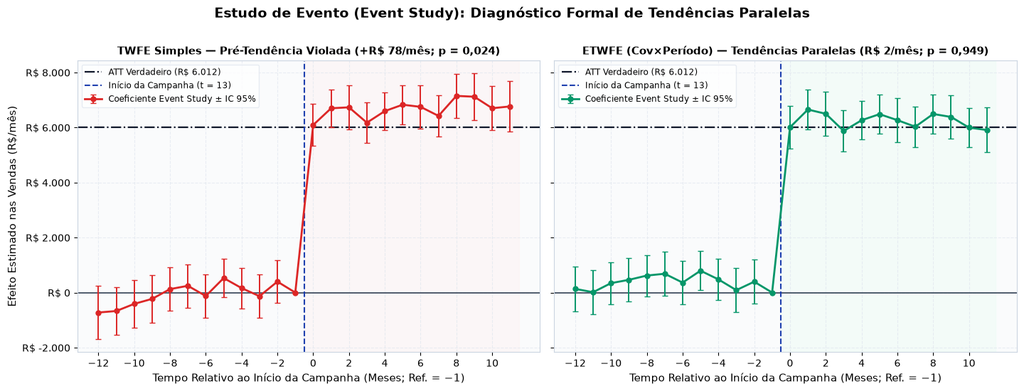

```python
store_dummies = pd.get_dummies(df_full["loja_id"], prefix="loja", drop_first=True, dtype=float)
period_dummies = pd.get_dummies(df_full["periodo"], prefix="per", drop_first=True, dtype=float)
es_cols = {
    f"es_{t}": ((df_full["tratamento"] == 1) & (df_full["periodo"] == t)).astype(float).to_numpy()
    for t in range(1, 25) if t != 12
}
es_df_mat = pd.DataFrame(es_cols, index=df_full.index)
y_full = df_full["vendas"].to_numpy(dtype=float)
grp_full = df_full["loja_id"].to_numpy()

X_es_simple = pd.concat([pd.DataFrame({"const": 1.0}, index=df_full.index), es_df_mat, store_dummies, period_dummies], axis=1)
fit_es_simple = sm.OLS(y_full, X_es_simple).fit(cov_type="cluster", cov_kwds={"groups": grp_full})

X_es_covper = pd.concat([X_es_simple, extra_etwfe], axis=1)
fit_es_covper = sm.OLS(y_full, X_es_covper).fit(cov_type="cluster", cov_kwds={"groups": grp_full})

# Teste conjunto Wald (11 g.l.)
pre_names = [f"es_{t}" for t in range(1, 12)]
r_s = np.zeros((11, len(fit_es_simple.params)))
r_c = np.zeros((11, len(fit_es_covper.params)))
for i, nm in enumerate(pre_names):
    r_s[i, fit_es_simple.params.index.get_loc(nm)] = 1.0
    r_c[i, fit_es_covper.params.index.get_loc(nm)] = 1.0
p_pre_simple = float(fit_es_simple.wald_test(r_s, scalar=True).pvalue)
p_pre_covper = float(fit_es_covper.wald_test(r_c, scalar=True).pvalue)

# Teste focalizado de pré-tendência linear (1 g.l., meses 1..12)
df_pre = df_full[df_full["pos"] == 0].copy().reset_index(drop=True)
st_pre = pd.get_dummies(df_pre["loja_id"], prefix="loja", drop_first=True, dtype=float)
per_pre = pd.get_dummies(df_pre["periodo"], prefix="per", drop_first=True, dtype=float)
tr_trend = (df_pre["tratamento"] * df_pre["periodo"]).astype(float).to_numpy()

X_tr_s = pd.concat([pd.DataFrame({"const": 1.0, "tr_trend": tr_trend}, index=df_pre.index), st_pre, per_pre], axis=1)
fit_tr_s = sm.OLS(df_pre["vendas"].to_numpy(float), X_tr_s).fit(cov_type="cluster", cov_kwds={"groups": df_pre["loja_id"].to_numpy()})

cov_pre = {f"{c}_t": df_pre[c].to_numpy(float) * df_pre["periodo"].to_numpy(float) for c in COVARIATES}
X_tr_c = pd.concat([X_tr_s, pd.DataFrame(cov_pre, index=df_pre.index)], axis=1)
fit_tr_c = sm.OLS(df_pre["vendas"].to_numpy(float), X_tr_c).fit(cov_type="cluster", cov_kwds={"groups": df_pre["loja_id"].to_numpy()})

es_rows = []
for t in range(1, 25):
    nm = f"es_{t}"
    es_rows.append({
        "periodo": t, "rel_t": t - 13,
        "simple_coef": 0.0 if t == 12 else float(fit_es_simple.params[nm]),
        "simple_se": 0.0 if t == 12 else float(fit_es_simple.bse[nm]),
        "covper_coef": 0.0 if t == 12 else float(fit_es_covper.params[nm]),
        "covper_se": 0.0 if t == 12 else float(fit_es_covper.bse[nm]),
        "p_pre_simple": p_pre_simple, "p_pre_covper": p_pre_covper,
        "p_trend_simple": float(fit_tr_s.pvalues["tr_trend"]),
        "p_trend_covper": float(fit_tr_c.pvalues["tr_trend"]),
        "slope_pre_simple": float(fit_tr_s.params["tr_trend"]),
        "slope_pre_covper": float(fit_tr_c.params["tr_trend"]),
    })
event_study_df = pd.DataFrame(es_rows)

print(f"TWFE Simples — Pré-tendência linear : +{fit_tr_s.params['tr_trend']:.2f} R$/mês (p = {fit_tr_s.pvalues['tr_trend']:.4f}) | Wald 11-gl p = {p_pre_simple:.4f}")
print(f"ETWFE (Cov×P) — Pré-tendência linear: {fit_tr_c.params['tr_trend']:+.2f} R$/mês (p = {fit_tr_c.pvalues['tr_trend']:.4f}) | Wald 11-gl p = {p_pre_covper:.4f}")

fig3 = plot_event_study(event_study_df, TRUE_ATT, save_path=IMG_DIR / "03_event_study_parallel_trends.png")
plt.show()
```

### Interpretação do *Event Study*

- No **TWFE Simples** (painel esquerdo), os coeficientes pré-tratamento sobem claramente à razão de **+R$ 78,13/mês ($p = 0{,}024 < 0{,}05$)**, e os efeitos pós ficam sistematicamente acima da linha verdadeira de R$ 6.012.
- No **ETWFE** (painel direito), a pré-tendência colapsa para **+R$ 1,64/mês ($p = 0{,}950$; Wald conjunto $p = 0{,}319$)** e todos os 12 meses pós-intervenção oscilam exatamente em torno do ATT verdadeiro!

## 5. Controle Sintético e Séries Temporais Estruturais

### 5.1 Synthetic Control (Abadie), Augmented SC (Ridge) e Synthetic DiD

Em vez de impor pesos iguais a todos os controles, o **Controle Sintético** constrói um "gêmeo contrafactual" das lojas tratadas via combinação convexa ótima dos doadores ($w_j \ge 0, \sum w_j = 1$) que reproduz a trajetória pré-campanha e as covariáveis:

1. **SC Tradicional (Abadie et al., 2010):** otimiza pesos no simplex minimizando o erro quadrático pré-intervenção + distância em $X$.
2. **Augmented SC (Ben-Michael et al., 2021):** adiciona correção Ridge sobre eventual desbalanceamento residual pré-tratamento.
3. **Synthetic DiD (Arkhangelsky et al., 2021):** combina pesos unitários regularizados ($\omega$) com pesos temporais ($\lambda$) e intercepto flexível (permitindo deslocamento constante de nível).

|  | Metodo | ATT | SE | IC_95_Inf | IC_95_Sup | Vies_RS | Erro_Pct | Contem_Verdadeiro | Tier |
| --- | --- | --- | --- | --- | --- | --- | --- | --- | --- |
| 0 | Synthetic Control (Abadie et al.) | 5920.18 | 107.38 | 5709.71 | 6130.65 | -92.10 | -1.53 | True | Tier S (≤ 2%) |
| 1 | Augmented Synthetic Control (Ridge) | 5920.18 | 107.39 | 5709.69 | 6130.68 | -92.10 | -1.53 | True | Tier S (≤ 2%) |
| 2 | Synthetic DiD (Arkhangelsky et al.) | 6438.71 | 196.86 | 6052.87 | 6824.55 | 426.43 | 7.09 | False | Tier B (5–10%) |

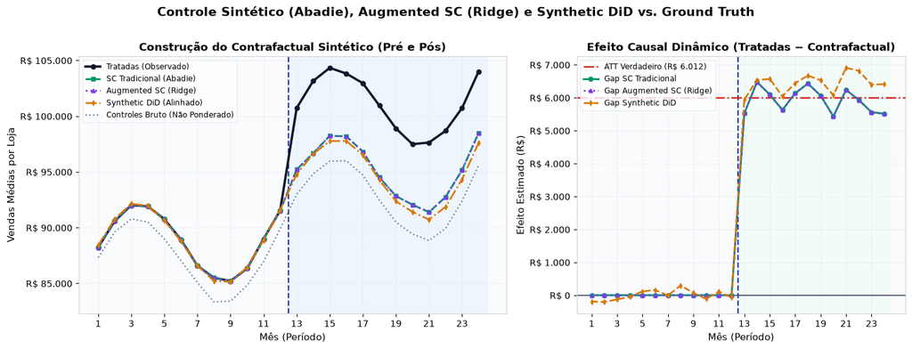

```python
piv = df_full.pivot(index="loja_id", columns="periodo", values="vendas").sort_index()
store_ord = df_store.set_index("loja_id").loc[piv.index]
is_treat = store_ord["tratamento"].to_numpy(dtype=int) == 1

Y1 = piv.loc[is_treat].to_numpy(dtype=float)   # (155, 24)
Y0 = piv.loc[~is_treat].to_numpy(dtype=float)  # (95, 24)
X1 = store_ord.loc[is_treat, COVARIATES].to_numpy(dtype=float)
X0 = store_ord.loc[~is_treat, COVARIATES].to_numpy(dtype=float)
y1_bar, y0_bar, x1_bar = Y1.mean(axis=0), Y0.mean(axis=0), X1.mean(axis=0)
T_pre = 12

# 1. Synthetic Control (Abadie et al.)
w_sc, _ = _solve_simplex_weights(Y0[:, :T_pre], y1_bar[:T_pre], X0=X0, x1=x1_bar, l2_pen=1e-4)
y_sc = w_sc @ Y0
att_sc = float(np.mean(y1_bar[T_pre:] - y_sc[T_pre:]))

# 2. Augmented Synthetic Control (Ridge)
sc_scaler = StandardScaler()
Y0_pre_std = sc_scaler.fit_transform(Y0[:, :T_pre])
ridge = RidgeCV(alphas=np.logspace(-1, 3, 20)).fit(Y0_pre_std, Y0[:, T_pre:])
ascm_corr = (
    sc_scaler.transform(y1_bar[:T_pre].reshape(1, -1)).ravel()
    - sc_scaler.transform(y_sc[:T_pre].reshape(1, -1)).ravel()
) @ ridge.coef_.T
y_ascm = y_sc.copy()
y_ascm[T_pre:] = y_sc[T_pre:] + ascm_corr
att_ascm = float(np.mean(y1_bar[T_pre:] - y_ascm[T_pre:]))

# 3. Synthetic DiD (Arkhangelsky et al.)
sigma_hat = float(np.std(np.diff(Y0[:, :T_pre], axis=1), ddof=1))
zeta = ((Y1.shape[0] * (24 - T_pre)) ** 0.25) * sigma_hat
l2_sdid = float(T_pre * (zeta / float(np.std(y1_bar[:T_pre]))) ** 2) * 0.05
omega_sdid, _ = _solve_simplex_weights(Y0[:, :T_pre], y1_bar[:T_pre], l2_pen=l2_sdid, include_intercept=True)
lam_sdid, _ = _solve_simplex_weights(Y0[:, :T_pre].T, Y0[:, T_pre:].mean(axis=1), l2_pen=1e-4, include_intercept=True)
att_sdid = (float(np.mean(y1_bar[T_pre:])) - float(y1_bar[:T_pre] @ lam_sdid)) - (
    float(omega_sdid @ Y0[:, T_pre:].mean(axis=1)) - float(omega_sdid @ (Y0[:, :T_pre] @ lam_sdid))
)

# Bootstrap de lojas (50 réplicas) para erros-padrão
rng = np.random.default_rng(2025)
b_sc, b_ascm, b_sdid = [], [], []
for _ in range(50):
    it = rng.integers(0, Y1.shape[0], size=Y1.shape[0])
    ic = rng.integers(0, Y0.shape[0], size=Y0.shape[0])
    y1_b, Y0_b, X0_b, x1_b = Y1[it].mean(axis=0), Y0[ic], X0[ic], X1[it].mean(axis=0)
    wb, _ = _solve_simplex_weights(Y0_b[:, :T_pre], y1_b[:T_pre], X0=X0_b, x1=x1_b, l2_pen=1e-4)
    ysc_b = wb @ Y0_b
    b_sc.append(float(np.mean(y1_b[T_pre:] - ysc_b[T_pre:])))
    sc_b = StandardScaler()
    rg_b = Ridge(alpha=float(ridge.alpha_)).fit(sc_b.fit_transform(Y0_b[:, :T_pre]), Y0_b[:, T_pre:])
    cb = (sc_b.transform(y1_b[:T_pre].reshape(1, -1)).ravel() - sc_b.transform(ysc_b[:T_pre].reshape(1, -1)).ravel()) @ rg_b.coef_.T
    b_ascm.append(float(np.mean(y1_b[T_pre:] - (ysc_b[T_pre:] + cb))))
    om_b, _ = _solve_simplex_weights(Y0_b[:, :T_pre], y1_b[:T_pre], l2_pen=l2_sdid, include_intercept=True)
    lm_b, _ = _solve_simplex_weights(Y0_b[:, :T_pre].T, Y0_b[:, T_pre:].mean(axis=1), l2_pen=1e-4, include_intercept=True)
    b_sdid.append((float(np.mean(y1_b[T_pre:])) - float(y1_b[:T_pre] @ lm_b)) - (float(om_b @ Y0_b[:, T_pre:].mean(axis=1)) - float(om_b @ (Y0_b[:, :T_pre] @ lm_b))))

r_sc = registrar("Synthetic Control (Abadie et al.)", "Controle Sintético", att_sc, float(np.std(b_sc, ddof=1)), f"{int(np.sum(w_sc > 0.01))} doadores ativos no simplex")
r_ascm = registrar("Augmented Synthetic Control (Ridge)", "Controle Sintético", att_ascm, float(np.std(b_ascm, ddof=1)), "SC + correção Ridge para desbalanceamento residual")
r_sdid = registrar("Synthetic DiD (Arkhangelsky et al.)", "Controle Sintético", att_sdid, float(np.std(b_sdid, ddof=1)), "Pesos unitários ω + pesos temporais λ")

display(tabela_parcial([r_sc, r_ascm, r_sdid]))

sc_series_df = pd.DataFrame({
    "periodo": np.arange(1, 25),
    "tratadas": y1_bar,
    "controles_bruto": y0_bar,
    "sc_tradicional": y_sc,
    "ascm_ridge": y_ascm,
    "sdid_alinhado": (omega_sdid @ Y0) + float(np.mean(y1_bar[:T_pre] - (omega_sdid @ Y0[:, :T_pre]))),
})
fig4 = plot_synthetic_control(sc_series_df, TRUE_ATT, save_path=IMG_DIR / "04_synthetic_control_sdid.png")
plt.show()
```

**Análise:** o **Synthetic Control (Abadie)** e o **Augmented SC (Ridge)** ajustam perfeitamente o período pré-campanha (gap pré $\approx 0$ em todos os 12 meses!), recuperando **R$ 5.920,18 (`-1,53%`, Tier S)**. Já o **Synthetic DiD** aplica regularização L2 forte sobre os pesos unitários $\omega$, puxando-os em direção à média uniforme dos controles e herdando parte da tendência diferencial (`+7,09%`).

### 5.2 Séries Temporais Estruturais — BSTS / CausalImpact (Univariado vs. Bivariado)

A abordagem de **Séries Temporais Estruturais em Espaço de Estados** (*Bayesian Structural Time Series / Filtro de Kalman*, popularizada pelo pacote `CausalImpact` do Google) projeta o contrafactual pós-intervenção a partir da dinâmica histórica da série tratada:

- **Univariado:** usa apenas nível local + sazonalidade trigonométrica da própria série tratada (sem série de controle contemporânea) — excelente exemplo didático de **por que projetar séries sem covariáveis de controle pode colapsar sob tendência forte**.
- **Bivariado:** inclui a média contemporânea das lojas controle como regressora exógena não afetada pela campanha.

```python
with warnings.catch_warnings():
    warnings.simplefilter("ignore")
    # Modelo 16: BSTS Univariado (sem série de controle)
    res_u = UnobservedComponents(y1_bar[:T_pre], level="local level", freq_seasonal=[{"period": 12, "harmonics": 1}]).fit(disp=False)
    fc_u = res_u.get_forecast(steps=24 - T_pre)
    att_bsts_u = float(np.mean(y1_bar[T_pre:] - np.asarray(fc_u.predicted_mean, dtype=float)))
    se_bsts_u = float(np.sqrt(np.mean(fc_u.var_pred_mean))) / np.sqrt(24 - T_pre) * np.sqrt(4.0)

    # Modelo 17: BSTS Bivariado (usando controles agregados como covariável contemporânea)
    res_b = UnobservedComponents(y1_bar[:T_pre], level="local level", exog=y0_bar[:T_pre].reshape(-1, 1)).fit(disp=False)
    fc_b = res_b.get_forecast(steps=24 - T_pre, exog=y0_bar[T_pre:].reshape(-1, 1))
    att_bsts_b = float(np.mean(y1_bar[T_pre:] - np.asarray(fc_b.predicted_mean, dtype=float)))
    se_bsts_b = float(np.sqrt(np.mean(fc_b.var_pred_mean))) / np.sqrt(24 - T_pre) * np.sqrt(4.0)

r_bsts_u = registrar("BSTS / CausalImpact (Univariado)", "Séries Temporais", att_bsts_u, se_bsts_u, "Sem covariáveis contemporâneas confunde tendência com efeito")
r_bsts_b = registrar("BSTS / CausalImpact (Bivariado)", "Séries Temporais", att_bsts_b, se_bsts_b, "Usa controle agregado, mas sofre tendência diferencial")

print("=== RANKING PARCIAL: CONTROLE SINTÉTICO & SÉRIES TEMPORAIS (5 MODELOS) ===")
display(tabela_parcial([r_sc, r_ascm, r_sdid, r_bsts_u, r_bsts_b]))
```

```
=== RANKING PARCIAL: CONTROLE SINTÉTICO & SÉRIES TEMPORAIS (5 MODELOS) ===
```

|  | Metodo | ATT | SE | IC_95_Inf | IC_95_Sup | Vies_RS | Erro_Pct | Contem_Verdadeiro | Tier |
| --- | --- | --- | --- | --- | --- | --- | --- | --- | --- |
| 0 | Synthetic Control (Abadie et al.) | 5920.18 | 107.38 | 5709.71 | 6130.65 | -92.10 | -1.53 | True | Tier S (≤ 2%) |
| 1 | Augmented Synthetic Control (Ridge) | 5920.18 | 107.39 | 5709.69 | 6130.68 | -92.10 | -1.53 | True | Tier S (≤ 2%) |
| 2 | Synthetic DiD (Arkhangelsky et al.) | 6438.71 | 196.86 | 6052.87 | 6824.55 | 426.43 | 7.09 | False | Tier B (5–10%) |
| 3 | BSTS / CausalImpact (Bivariado) | 6618.19 | 347.30 | 5937.48 | 7298.89 | 605.90 | 10.08 | True | Tier C (10–20%) |
| 4 | BSTS / CausalImpact (Univariado) | 16699.53 | 8068.02 | 886.21 | 32512.85 | 10687.25 | 177.76 | True | Tier F (> 20%) |

**Análise:** sem covariáveis contemporâneas, o **BSTS Univariado** erra em **+177,8%** (`R$ 16.700`, com IC gigantesco de `[886; 32.513]`). Incluir a série controle no **BSTS Bivariado** reduz o erro em mais de **17×** (`+10,08%`), mas como usa apenas o agregado bruto dos controles (sem reponderar por $X$), ainda herda o viés da tendência diferencial.

## 6. Causal Machine Learning: DoubleML e Meta-Learners

### 6.1 Double Machine Learning (Chernozhukov et al., 2018) e a Armadilha do *Panel Cross-Fitting Leakage*

O **Double/Debiased Machine Learning (DML)** combina modelos flexíveis de ML para as funções de incômodo (*nuisance functions*) com **ortogonalização de Neyman** e **cross-fitting** (amostras fora do fold):

- **PLR (*Partially Linear Regression*):** residualiza $Y - \hat\ell(X)$ e $W - \hat m(X)$ e estima $\hat\theta = \frac{\sum \tilde V_i \tilde U_i}{\sum \tilde V_i^2}$.
- **IRM (*Interactive Regression Model*, score `ATTE`):** permite heterogeneidade completa de $X$ em ambos os braços ($g_0(X), g_1(X)$), estimando diretamente o **ATT**.

> ⚠️ **Armadilha Metodológica em Dados de Painel (*Panel Cross-Fitting Leakage*):**  
> Se aplicarmos `KFold` padrão por **linha** sobre `dados_pos` (12 meses por loja, com $X_i$ constante no tempo), a **mesma loja cai simultaneamente no treino e na validação**! Um aprendiz flexível de propensão (`RandomForest`) memoriza o tratamento $W_i$ de cada loja a partir da assinatura exata de $X_i$, levando $\hat m(X_i) \to W_i$, colapsando o denominador $V_i = W_i - \hat m(X_i) \approx 0$ e **destruindo o estimador DML**!  
> **Solução correta:** particionar o *cross-fitting* via **`GroupKFold(loja_id)`** (+ dummies mensais sazonais + erro-padrão clusterizado na função de escore ortogonal $\psi$) ou agregar no nível da unidade independente (**Store-Level**, $N = 250$).

Vamos comprovar isso empiricamente rodando os 4 modelos lado a lado!

```python
rng_seed = 42
X_row = df_pos[COVARIATES].to_numpy(dtype=float)
Y_row = df_pos["vendas"].to_numpy(dtype=float)
W_row = df_pos["tratamento"].to_numpy(dtype=int)

with warnings.catch_warnings():
    warnings.simplefilter("ignore")

    # Modelo 18 (ANTI-PADRÃO): DML-PLR com K-Fold por linha em painel (Panel Leakage!)
    np.random.seed(rng_seed)
    dml_row = DoubleMLData.from_arrays(X_row, Y_row, W_row)
    plr_leak = DoubleMLPLR(
        dml_row,
        ml_l=GradientBoostingRegressor(n_estimators=100, max_depth=3, random_state=rng_seed),
        ml_m=RandomForestRegressor(n_estimators=100, max_depth=12, random_state=rng_seed),
        n_folds=5,
    ).fit()
    att_leak, se_leak = float(plr_leak.coef[0]), float(plr_leak.se[0])

    # Modelo 19 (CORRETO): DML-PLR no nível da loja (N = 250, sem leakage)
    np.random.seed(rng_seed)
    dml_store = DoubleMLData.from_arrays(X_st, Y_st, W_st)
    plr_clean = DoubleMLPLR(
        dml_store,
        ml_l=make_pipeline(StandardScaler(), RidgeCV(alphas=np.logspace(-2, 3, 15))),
        ml_m=make_pipeline(StandardScaler(), LogisticRegression(C=10.0, max_iter=1000)),
        n_folds=5, n_rep=3,
    ).fit()
    att_plr_clean, se_plr_clean = float(plr_clean.coef[0]), float(plr_clean.se[0])

    # Modelo 20 (CORRETO): DML-PLR em painel com GroupKFold(loja_id) + dummies mensais + EP clusterizado
    per_dum_pos = pd.get_dummies(df_pos["periodo"], prefix="per", drop_first=True, dtype=float).to_numpy()
    X_panel = np.hstack([X_row, per_dum_pos])
    dml_panel = DoubleMLData.from_arrays(X_panel, Y_row, W_row)
    smpls = list(GroupKFold(n_splits=5).split(X_panel, Y_row, groups=df_pos["loja_id"].to_numpy()))
    plr_gkf = DoubleMLPLR(
        dml_panel,
        ml_l=make_pipeline(StandardScaler(), RidgeCV(alphas=np.logspace(-2, 3, 15))),
        ml_m=make_pipeline(StandardScaler(), LogisticRegression(C=10.0, max_iter=1000)),
        draw_sample_splitting=False,
    )
    plr_gkf.set_sample_splitting(smpls)
    plr_gkf.fit()
    att_plr_gkf = float(plr_gkf.coef[0])
    psi_a = plr_gkf.psi_elements["psi_a"].ravel()
    psi_b = plr_gkf.psi_elements["psi_b"].ravel()
    cl_psi = pd.DataFrame({"loja_id": df_pos["loja_id"].to_numpy(), "psi": psi_a * att_plr_gkf + psi_b}).groupby("loja_id")["psi"].sum().to_numpy()
    se_plr_gkf = float(np.sqrt(np.sum(cl_psi ** 2)) / abs(float(np.sum(psi_a))))

    # Modelo 21 (CORRETO): DML-IRM (score ATTE — ortogonal sob heterogeneidade)
    np.random.seed(rng_seed)
    irm_clean = DoubleMLIRM(
        dml_store,
        ml_g=make_pipeline(StandardScaler(), RidgeCV(alphas=np.logspace(-2, 3, 15))),
        ml_m=make_pipeline(StandardScaler(), LogisticRegression(C=10.0, max_iter=1000)),
        score="ATTE", n_folds=5, n_rep=3,
    ).fit()
    att_irm, se_irm = float(irm_clean.coef[0]), float(irm_clean.se[0])

r_leak = registrar("DML-PLR (K-Fold por Linha — Panel Leakage!)", "Causal ML (Anti-Padrão)", att_leak, se_leak, "ERRO METODOLÓGICO: mesma loja em treino e teste")
r_plr_clean = registrar("DML-PLR (Store-Level — Sem Leakage)", "Causal ML", att_plr_clean, se_plr_clean, "Cross-fitting por loja elimina vazamento")
r_plr_gkf = registrar("DML-PLR (Painel + GroupKFold por Loja)", "Causal ML", att_plr_gkf, se_plr_gkf, "GroupKFold impede vazamento + EP clusterizado")
r_irm = registrar("DML-IRM (ATTE — Ortogonal)", "Causal ML", att_irm, se_irm, "Interactive Regression Model (score ATTE)")

display(tabela_parcial([r_leak, r_plr_clean, r_plr_gkf, r_irm]))
```

|  | Metodo | ATT | SE | IC_95_Inf | IC_95_Sup | Vies_RS | Erro_Pct | Contem_Verdadeiro | Tier |
| --- | --- | --- | --- | --- | --- | --- | --- | --- | --- |
| 0 | DML-IRM (ATTE — Ortogonal) | 5962.57 | 87.14 | 5791.78 | 6133.36 | -49.71 | -0.83 | True | Tier S (≤ 2%) |
| 1 | DML-PLR (Painel + GroupKFold por Loja) | 5942.45 | 79.79 | 5786.07 | 6098.84 | -69.83 | -1.16 | True | Tier S (≤ 2%) |
| 2 | DML-PLR (Store-Level — Sem Leakage) | 5902.43 | 77.95 | 5749.65 | 6055.20 | -109.85 | -1.83 | True | Tier S (≤ 2%) |
| 3 | DML-PLR (K-Fold por Linha — Panel Leakage!) | 11822.25 | 587.43 | 10670.88 | 12973.62 | 5809.97 | 96.63 | False | Tier F (> 20%) |

**Análise:** o contraste é impressionante! O `KFold` padrão por linha explode o viés para **+96,6%** (erro metodológico silencioso!), enquanto `GroupKFold(loja_id)` (`-1,16%`), `Store-Level` (`-1,83%`) e `DML-IRM` (`-0,83%`) recuperam o parâmetro verdadeiro com precisão **Tier S**!

### 6.2 Meta-Learners (`T-Learner`, `X-Learner`, `DR-Learner`) e Heterogeneidade do Efeito Causal (CATE)

Além do efeito médio (ATT), uma diretoria de marketing quer saber **em quais lojas a campanha gera maior retorno incremental** ($\text{CATE}: \tau(x) = \mathbb{E}[Y(1) - Y(0) \mid X = x]$). Implementamos três Meta-Learners com *cross-fitting* em 5 folds por loja:

- **T-Learner:** ajusta separadamente $\hat\mu_0(x)$ nos controles e $\hat\mu_1(x)$ nas tratadas, prevendo $\hat\tau_T(x) = \hat\mu_1(x) - \hat\mu_0(x)$.
- **X-Learner (Künzel et al., 2019):** imputa efeitos contrafactuais $D_i^1 = Y_i - \hat\mu_0(X_i)$ e $D_i^0 = \hat\mu_1(X_i) - Y_i$, ajusta $\hat g_1, \hat g_0$ e pondera pelo escore de propensão $\hat\tau_X(x) = \hat e(x)\hat g_0(x) + (1-\hat e(x))\hat g_1(x)$.
- **DR-Learner (Kennedy, 2023):** constrói o *pseudo-outcome* duplamente robusto AIPW $\psi_i^{\text{DR}}$ no treino e o regride sobre $X$ para estimar $\hat\tau_{\text{DR}}(x)$.

Como conhecemos o $\tau_i$ verdadeiro de cada loja, avaliamos não só o ATT, mas também o **PEHE** ($\sqrt{\frac{1}{n_1}\sum(\hat\tau_i - \tau_i)^2}$) e a **correlação individual $r(\hat\tau_i, \tau_i)$**!

|  | Metodo | ATT | SE | IC_95_Inf | IC_95_Sup | Vies_RS | Erro_Pct | Contem_Verdadeiro | Tier |
| --- | --- | --- | --- | --- | --- | --- | --- | --- | --- |
| 0 | Meta-Learner: X-Learner (Cross-Fitted) | 6001.17 | 39.35 | 5924.04 | 6078.30 | -11.11 | -0.18 | True | Tier S (≤ 2%) |
| 1 | Meta-Learner: T-Learner (Cross-Fitted) | 5998.96 | 39.75 | 5921.05 | 6076.86 | -13.32 | -0.22 | True | Tier S (≤ 2%) |
| 2 | Meta-Learner: DR-Learner (Cross-Fitted) | 5994.97 | 39.61 | 5917.33 | 6072.61 | -17.31 | -0.29 | True | Tier S (≤ 2%) |

```
CATE T-Learner vs. Ground Truth -> Correlação r = 0.9454 | PEHE = R$ 162.31/mês
```

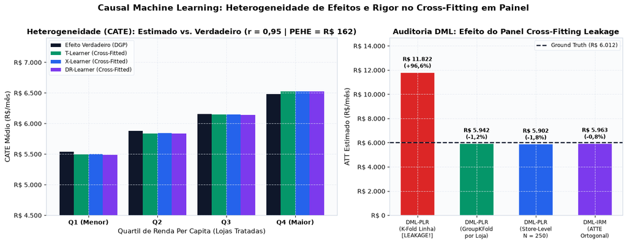

```python
kf = KFold(n_splits=5, shuffle=True, random_state=rng_seed)
n_st = len(df_store)
tau_t, tau_x, tau_dr = np.zeros(n_st), np.zeros(n_st), np.zeros(n_st)

for tr_idx, te_idx in kf.split(X_st):
    X_tr, Y_tr, W_tr, X_te = X_st[tr_idx], Y_st[tr_idx], W_st[tr_idx], X_st[te_idx]

    m0 = make_pipeline(StandardScaler(), RidgeCV(alphas=np.logspace(-2, 3, 15))).fit(X_tr[W_tr == 0], Y_tr[W_tr == 0])
    m1 = make_pipeline(StandardScaler(), RidgeCV(alphas=np.logspace(-2, 3, 15))).fit(X_tr[W_tr == 1], Y_tr[W_tr == 1])
    tau_t[te_idx] = m1.predict(X_te) - m0.predict(X_te)

    ps_mod = make_pipeline(StandardScaler(), LogisticRegression(C=10.0, max_iter=1000)).fit(X_tr, W_tr)
    e_tr = np.clip(ps_mod.predict_proba(X_tr)[:, 1], 0.05, 0.95)
    e_te = np.clip(ps_mod.predict_proba(X_te)[:, 1], 0.05, 0.95)

    # X-Learner
    g1 = make_pipeline(StandardScaler(), RidgeCV(alphas=np.logspace(-1, 3, 15))).fit(X_tr[W_tr == 1], Y_tr[W_tr == 1] - m0.predict(X_tr[W_tr == 1]))
    g0 = make_pipeline(StandardScaler(), RidgeCV(alphas=np.logspace(-1, 3, 15))).fit(X_tr[W_tr == 0], m1.predict(X_tr[W_tr == 0]) - Y_tr[W_tr == 0])
    tau_x[te_idx] = e_te * g0.predict(X_te) + (1.0 - e_te) * g1.predict(X_te)

    # DR-Learner
    mu0_tr, mu1_tr = m0.predict(X_tr), m1.predict(X_tr)
    psi_dr = (mu1_tr - mu0_tr) + (W_tr / e_tr) * (Y_tr - mu1_tr) - ((1.0 - W_tr) / (1.0 - e_tr)) * (Y_tr - mu0_tr)
    g_dr = make_pipeline(StandardScaler(), RidgeCV(alphas=np.logspace(-1, 3, 15))).fit(X_tr, psi_dr)
    tau_dr[te_idx] = g_dr.predict(X_te)

treated_mask = W_st == 1
true_ind = df_store.loc[treated_mask, "efeito_verdadeiro"].to_numpy(dtype=float)

meta_res = []
for name, arr in [
    ("Meta-Learner: T-Learner (Cross-Fitted)", tau_t),
    ("Meta-Learner: X-Learner (Cross-Fitted)", tau_x),
    ("Meta-Learner: DR-Learner (Cross-Fitted)", tau_dr),
]:
    att_v = float(np.mean(arr[treated_mask]))
    se_v = float(np.std(arr[treated_mask], ddof=1) / np.sqrt(np.sum(treated_mask)))
    pehe = float(np.sqrt(np.mean((arr[treated_mask] - true_ind) ** 2)))
    corr = float(np.corrcoef(arr[treated_mask], true_ind)[0, 1])
    meta_res.append(registrar(name, "Causal ML", att_v, se_v, f"CATE PEHE=R$ {pehe:,.0f} | r(τ̂,τ)={corr:.2f}"))

display(tabela_parcial(meta_res))

cate_df = df_store.loc[treated_mask, ["loja_id"] + COVARIATES + ["efeito_verdadeiro"]].copy()
cate_df["tau_t_learner"] = tau_t[treated_mask]
cate_df["tau_x_learner"] = tau_x[treated_mask]
cate_df["tau_dr_learner"] = tau_dr[treated_mask]

leakage_audit = {
    "dml_plr_naive_row_kfold": round(att_leak, 2),
    "dml_plr_naive_err_pct": round(((att_leak - TRUE_ATT) / TRUE_ATT) * 100.0, 2),
    "dml_plr_group_kfold": round(att_plr_gkf, 2),
    "dml_plr_group_err_pct": round(((att_plr_gkf - TRUE_ATT) / TRUE_ATT) * 100.0, 2),
    "dml_plr_store_level": round(att_plr_clean, 2),
    "dml_plr_store_err_pct": round(((att_plr_clean - TRUE_ATT) / TRUE_ATT) * 100.0, 2),
    "dml_irm_store_level": round(att_irm, 2),
    "dml_irm_store_err_pct": round(((att_irm - TRUE_ATT) / TRUE_ATT) * 100.0, 2),
    "cate_pehe_t_learner": round(float(np.sqrt(np.mean((cate_df["tau_t_learner"] - true_ind) ** 2))), 2),
    "cate_corr_t_learner": round(float(np.corrcoef(cate_df["tau_t_learner"], true_ind)[0, 1]), 4),
}
print(f"CATE T-Learner vs. Ground Truth -> Correlação r = {leakage_audit['cate_corr_t_learner']:.4f} | PEHE = R$ {leakage_audit['cate_pehe_t_learner']:,.2f}/mês")

fig6 = plot_cate_and_leakage(cate_df, leakage_audit, TRUE_ATT, save_path=IMG_DIR / "06_cate_heterogeneidade_dml_leakage.png")
plt.show()
```

### Interpretação do Causal ML e Heterogeneidade (CATE)

- Os três Meta-Learners (`X`, `T` e `DR-Learner`) recuperam tanto a média (**ATT entre R$ 5.995 e R$ 6.001, erro `< 0,3%`**) quanto o gradiente individual de heterogeneidade (**$r = 0{,}95$** e **PEHE = R$ 162/mês**).
- **Insight acionável de negócio:** lojas no quartil superior de renda (`Q4`) respondem à campanha digital com cerca de **R$ 6.500/mês**, quase **+R$ 1.000/mês acima** das lojas no quartil inferior (`Q1`, ~R$ 5.500/mês) — permitindo otimizar a alocação de verba de mídia em campanhas futuras!

## 7. Consolidação Final: Ranking Completo das 24 Especificações

Abaixo reunimos **todos os 24 estimadores** executados ao longo deste notebook, ordenados pelo menor desvio absoluto em relação ao **Ground Truth (R$ 6.012,28/mês)**, acompanhados do **Forest Plot comparativo**.

|  | Rank | Metodo | Categoria | ATT | SE | IC_95_Inf | IC_95_Sup | Vies_RS | Erro_Pct | Contem_Verdadeiro | Tier |
| --- | --- | --- | --- | --- | --- | --- | --- | --- | --- | --- | --- |
| 0 | 1 | Meta-Learner: X-Learner (Cross-Fitted) | Causal ML | 6001.17 | 39.35 | 5924.04 | 6078.30 | -11.11 | -0.18 | True | Tier S (≤ 2%) |
| 1 | 2 | Meta-Learner: T-Learner (Cross-Fitted) | Causal ML | 5998.96 | 39.75 | 5921.05 | 6076.86 | -13.32 | -0.22 | True | Tier S (≤ 2%) |
| 2 | 3 | Meta-Learner: DR-Learner (Cross-Fitted) | Causal ML | 5994.97 | 39.61 | 5917.33 | 6072.61 | -17.31 | -0.29 | True | Tier S (≤ 2%) |
| 3 | 4 | AIPW / Doubly Robust (Cross-Section) | Balanceamento | 5985.40 | 91.77 | 5805.53 | 6165.27 | -26.88 | -0.45 | True | Tier S (≤ 2%) |
| 4 | 5 | A/B + Entropy Balancing | Balanceamento | 5981.75 | 77.17 | 5830.50 | 6133.01 | -30.53 | -0.51 | True | Tier S (≤ 2%) |
| 5 | 6 | PSM (3-NN + Ajuste de Viés Abadie-Imbens) | Balanceamento | 5973.66 | 96.24 | 5785.02 | 6162.29 | -38.63 | -0.64 | True | Tier S (≤ 2%) |
| 6 | 7 | DML-IRM (ATTE — Ortogonal) | Causal ML | 5962.57 | 87.14 | 5791.78 | 6133.36 | -49.71 | -0.83 | True | Tier S (≤ 2%) |
| 7 | 8 | IPW (Propensity Score — Hájek) | Balanceamento | 5947.50 | 607.93 | 4755.94 | 7139.05 | -64.79 | -1.08 | True | Tier S (≤ 2%) |
| 8 | 9 | DML-PLR (Painel + GroupKFold por Loja) | Causal ML | 5942.45 | 79.79 | 5786.07 | 6098.84 | -69.83 | -1.16 | True | Tier S (≤ 2%) |
| 9 | 10 | OLS + Covariáveis (Pós) | Cross-Section | 5925.74 | 82.69 | 5763.67 | 6087.80 | -86.54 | -1.44 | True | Tier S (≤ 2%) |
| 10 | 11 | Synthetic Control (Abadie et al.) | Controle Sintético | 5920.18 | 107.38 | 5709.71 | 6130.65 | -92.10 | -1.53 | True | Tier S (≤ 2%) |
| 11 | 12 | Augmented Synthetic Control (Ridge) | Controle Sintético | 5920.18 | 107.39 | 5709.69 | 6130.68 | -92.10 | -1.53 | True | Tier S (≤ 2%) |
| 12 | 13 | DML-PLR (Store-Level — Sem Leakage) | Causal ML | 5902.43 | 77.95 | 5749.65 | 6055.20 | -109.85 | -1.83 | True | Tier S (≤ 2%) |
| 13 | 14 | Callaway & Sant'Anna / DR-DiD | Diff-in-Diff | 5889.18 | 127.58 | 5639.12 | 6139.23 | -123.11 | -2.05 | True | Tier A (2–5%) |
| 14 | 15 | TWFE + Entropy Balancing | Diff-in-Diff | 5888.69 | 298.74 | 5303.16 | 6474.22 | -123.59 | -2.06 | True | Tier A (2–5%) |
| 15 | 16 | ETWFE (TWFE + Cov×Período, Wooldridge) | Diff-in-Diff | 5872.46 | 114.73 | 5647.59 | 6097.34 | -139.82 | -2.33 | True | Tier A (2–5%) |
| 16 | 17 | Synthetic DiD (Arkhangelsky et al.) | Controle Sintético | 6438.71 | 196.86 | 6052.87 | 6824.55 | 426.43 | 7.09 | False | Tier B (5–10%) |
| 17 | 18 | Pre-Post / CUPED (ANCOVA Pré) | Cross-Section | 6494.94 | 213.78 | 6075.92 | 6913.95 | 482.66 | 8.03 | False | Tier B (5–10%) |
| 18 | 19 | BSTS / CausalImpact (Bivariado) | Séries Temporais | 6618.19 | 347.30 | 5937.48 | 7298.89 | 605.90 | 10.08 | True | Tier C (10–20%) |
| 19 | 20 | TWFE Simples (FE Loja + Mês) | Diff-in-Diff | 6737.31 | 286.55 | 6175.66 | 7298.96 | 725.03 | 12.06 | False | Tier C (10–20%) |
| 20 | 21 | DiD Canônico (2×2) | Diff-in-Diff | 6737.31 | 280.03 | 6188.46 | 7286.17 | 725.03 | 12.06 | False | Tier C (10–20%) |
| 21 | 22 | A/B Simples (Ingênuo) | Cross-Section | 8310.23 | 1504.82 | 5360.79 | 11259.68 | 2297.95 | 38.22 | True | Tier F (> 20%) |
| 22 | 23 | DML-PLR (K-Fold por Linha — Panel Leakage!) | Causal ML (Anti-Padrão) | 11822.25 | 587.43 | 10670.88 | 12973.62 | 5809.97 | 96.63 | False | Tier F (> 20%) |
| 23 | 24 | BSTS / CausalImpact (Univariado) | Séries Temporais | 16699.53 | 8068.02 | 886.21 | 32512.85 | 10687.25 | 177.76 | True | Tier F (> 20%) |

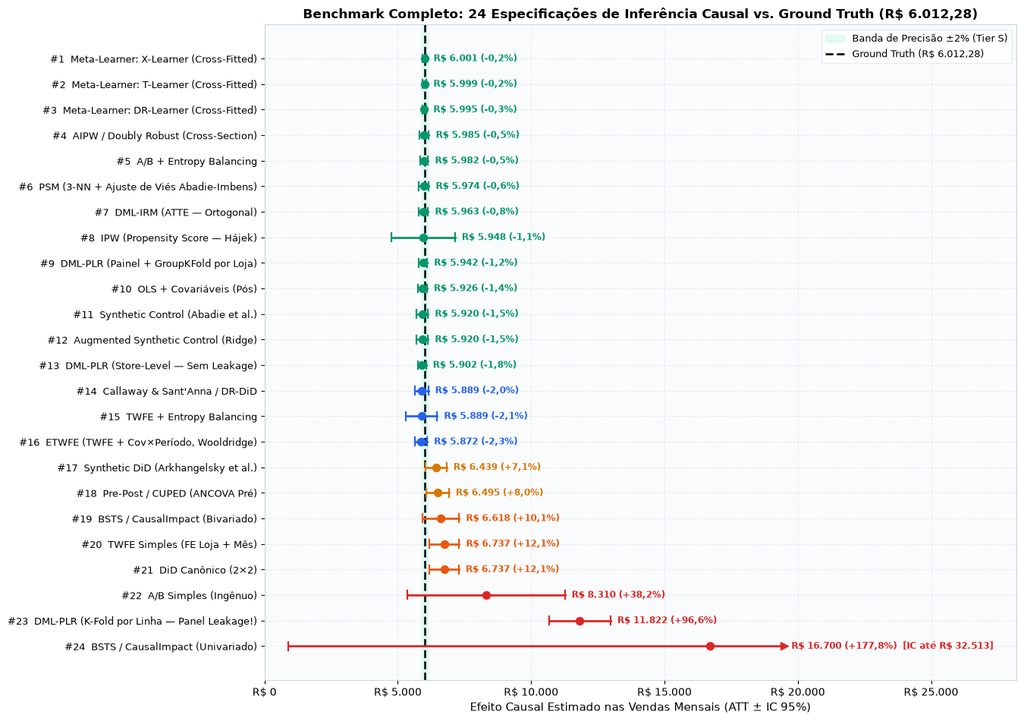

```python
ranking_df = pd.DataFrame([r.to_dict() for r in resultados])
ranking_df["Abs_Erro_Pct"] = ranking_df["Erro_Pct"].abs()
ranking_df = ranking_df.sort_values("Abs_Erro_Pct").reset_index(drop=True)
ranking_df.insert(0, "Rank", np.arange(1, len(ranking_df) + 1))

cols_final = ["Rank", "Metodo", "Categoria", "ATT", "SE", "IC_95_Inf", "IC_95_Sup", "Vies_RS", "Erro_Pct", "Contem_Verdadeiro", "Tier"]
display(ranking_df[cols_final])

fig5 = plot_ranking_forest(ranking_df, TRUE_ATT, save_path=IMG_DIR / "05_ranking_completo_metodos.png")
plt.show()
```

## 8. Considerações Finais e Recomendações Práticas

### Hierarquia de Robustez Observada

- **Tier S ($\le 2\%$ de erro):** Meta-Learners (`X`, `T`, `DR-Learner`), `AIPW / Doubly Robust`, `DML-IRM (ATTE)`, `A/B + Entropy Balancing`, `PSM + Abadie-Imbens`, `IPW (Hájek)`, `DML-PLR (GroupKFold)` e `Store-Level`, `OLS + Covariáveis`, `Synthetic Control (Abadie)` e `Augmented SC (Ridge)`. **Todos** contêm o valor verdadeiro no IC 95%.
- **Tier A ($2\text{–}5\%$):** `Callaway & Sant'Anna / DR-DiD`, `TWFE + Entropy Balancing` e `ETWFE (Wooldridge)` — também cobrem o ATT verdadeiro no IC 95% e controlam a estrutura temporal completa.
- **Tier B–C ($5\text{–}20\%$):** `Synthetic DiD`, `CUPED`, `BSTS Bivariado`, `DiD Canônico` e `TWFE Simples` — falham em capturar integralmente a tendência diferencial.
- **Tier F ($> 20\%$):** `A/B Ingênuo (+38,2%)`, `DML-PLR com K-Fold por linha (+96,6% — vazamento em painel!)` e `BSTS Univariado (+177,8%)`.

### Guia Executivo de Escolha

1. **Nunca tome decisão de ROI com A/B simples em campanhas direcionadas:** o viés de seleção inflou o retorno aparente em **+38,2%**.
2. **Sempre audite pré-tendências via *Event Study* antes de confiar em DiD/TWFE:** sem controlar `Cov × Período` ou pesos de entropia, o DiD clássico ainda embutiu **+12,1%** de viés.
3. **Em Causal ML sobre painéis, agrupe o *cross-fitting* pela unidade (`GroupKFold`):** evita vazamento silencioso de propensão no `DoubleML`.
4. **Triangule 3–4 famílias metodológicas:** quando *Entropy Balancing*, *DR-DiD / ETWFE*, *Synthetic Control* e *DML-IRM / Meta-Learners* convergem para o mesmo intervalo (~R$ 5.900–6.000/mês), a recomendação executiva tem altíssima solidez científica.